# Regressão Logística

# Pré-processamento

Para executar nosso primeiro exemplo de regressão linear, iremos utilizar a base de dados [Tiranic](https://github.com/claudioalvesmonteiro/nice-data-repo/blob/master/data/titanic_data.csv), onde consta informações sobre cada tripulante (sexo, idade, classe, etc.) e se o(a) tripulantes sobreviveu ou não, esta última informação será nossa variável dependente. Assim vamos analisar o efeito das variáveis independentes sobre a **probabilidade de sobrevivência no Titanic**.

**Implementar:** Baixe o banco de dados e carregue-o para o R;

**Implementar:** Crie um banco de dados a partir do titanic_data, apenas com as colunas “Survived”, “Pclass”, “Sex”, “Age”, “Fare”. Após isso verifique a existência de casos faltantes nas colunas e caso houver, realize algum tipo de tratamento.

| **Variable** | **Definition** | **Key** |
| --- | --- | --- |
| Survived | Survival | 0 = No, 1 = Yes |
| Pclass | Ticket class | 1 = 1st, 2 = 2nd, 3 = 3rd |
| Sex | Sex |  |
| Age | Age in years |  |
| SibSp | No. of siblings / spouses aboard the Titanic |  |
| Parch | No. of parents / children aboard the Titanic |  |
| Ticket | Ticket number |  |
| Fare | Passenger fare |  |
| Cabin | Cabin number |  |
| Embarked | Port of Embarkation | C = Cherbourg, Q = Queenstown, S = Southampton |

# Modelagem

A função para executar regressão logística é `glm`, que significa generalized linear models. Sua implementação segue a mesma estrutura de um modelo `lm`, apenas adiciona-se o argumento `family = "binomial"` ao código.

**Implementar:** O modelo de regressão logística para as variáveis selecionadas anteriormente, onde a sobrevivência é nossa VD.

```r
summary(modelo1)
```

```
##
## Call:
## glm(formula = Survived ~ Pclass + Sex + Age + Fare, family = "binomial",
##     data = titanic)
##
## Deviance Residuals:
##     Min       1Q   Median       3Q      Max
## -2.7386  -0.6792  -0.3954   0.6488   2.4642
##
## Coefficients:
##               Estimate Std. Error z value Pr(>|z|)
## (Intercept)  4.9880403  0.5721894   8.717  < 2e-16 ***
## Pclass      -1.2697410  0.1586252  -8.005 1.20e-15 ***
## Sexmale     -2.5181969  0.2078562 -12.115  < 2e-16 ***
## Age         -0.0367073  0.0076795  -4.780 1.75e-06 ***
## Fare         0.0005373  0.0021821   0.246    0.805
## ---
## Signif. codes:  0 '***' 0.001 '**' 0.01 '*' 0.05 '.' 0.1 ' ' 1
##
## (Dispersion parameter for binomial family taken to be 1)
##
##     Null deviance: 964.52  on 713  degrees of freedom
## Residual deviance: 647.23  on 709  degrees of freedom
## AIC: 657.23
##
## Number of Fisher Scoring iterations: 5
```

Podemos também visualizar os resultados de um modelo de regresão logística, com o pacote stargazer. Uma diferença em relação ao modelo linear é o argumento `apply.coef = exp`. Sabendo disso, **execute** a funcao `stargazer` para o modelo1.

```
##
## Model Results
## -------------------------------
##                     Survived
## -------------------------------
## Pclass              0.281***
##                      (0.159)
## Sexmale             0.081***
##                      (0.208)
## Age                 0.964***
##                      (0.008)
## Fare                  1.001
##                      (0.002)
## Constant           146.649***
##                      (0.572)
## N                      714
## Log Likelihood      -323.615
## AIC                  657.230
## -------------------------------
## ***p < .01; **p < .05; *p < .1
```

# Visualização de Dados

## Gráfico de Dispersão

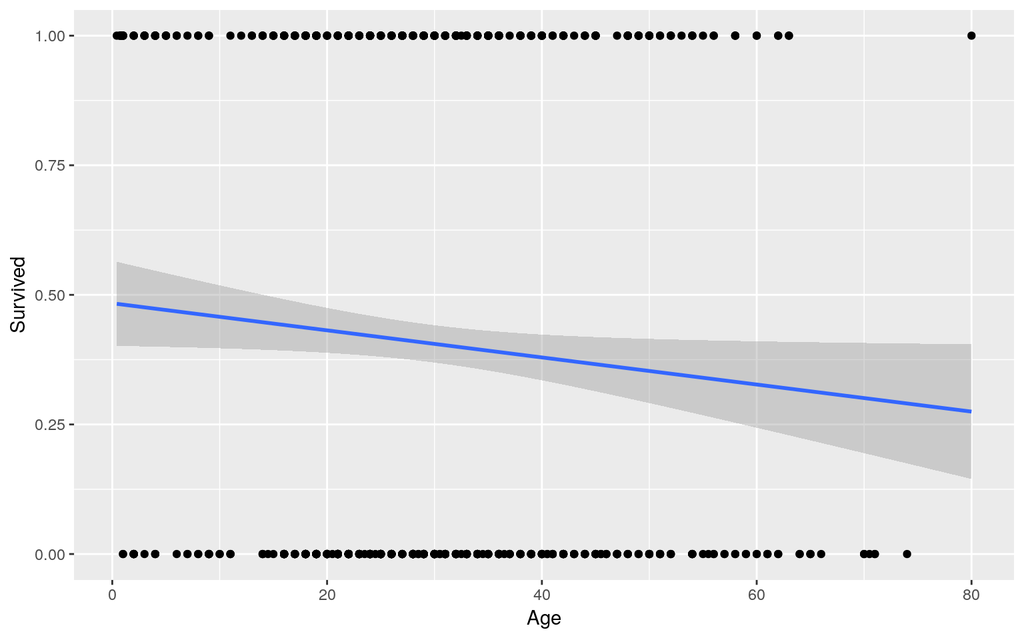

```r
# grafico de dispersao + reta de estimativa do modelo
library(ggplot2)
ggplot(data = titanic, aes(x = Age, y = Survived))+
  geom_point()+
  geom_smooth(method = "lm")
```

# Exercício

##### Implementar um modelo de regressão logística para o banco de dados [acidentes_transito_looptreat](https://github.com/claudioalvesmonteiro/nice-data-repo/blob/master/data/acidentes_transito_looptreat.csv), onde a variável dependente é `vitima`, que registra se naquele determinado acidente houve alguma vítima ou não. Como variáveis independentes: (1) escolha pelo menos dois bairros e dois endereços para analisar o efeito de cada; e (2) numero de automoveis envolvidos. Fique à vontade para analisar outras variáveis.

Analytique Consultoria

Janeiro, 2018